# Final Project

Luke O’Sullivan and Anand

November 6, 2016

# GDP of Uganda, USA and Canada

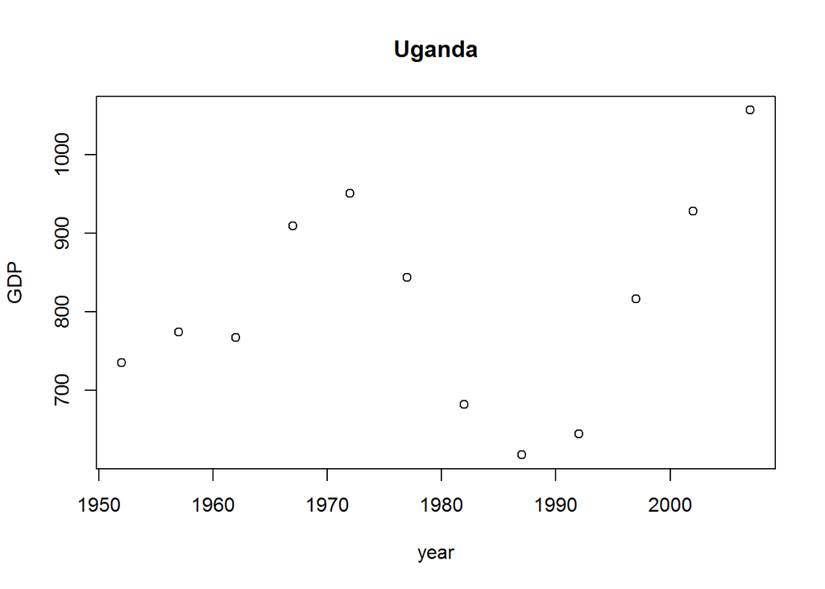

Uganda’s GDP Increases upto 1970s , takes a dip in the 80s and then has been increasing after that. *

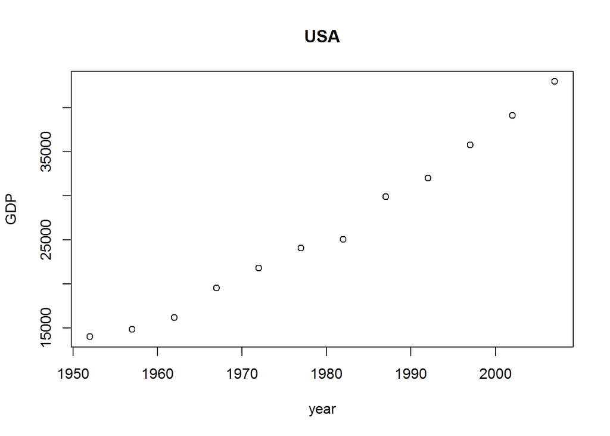

*USA’s GDP has seen constant increases from the 50s to the 2000s.*

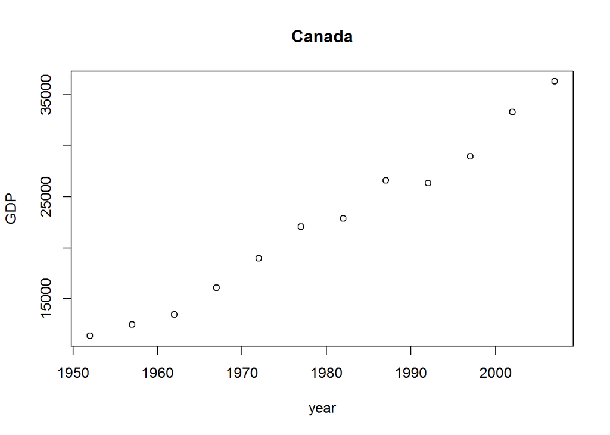

*Canada’s GDP has seen constant increases from the 50s to the 2000s.*

## Life Expectancy values in each continent

—————————————- Africa ——————————–  
The mean value of life expectancy for Africa is 48.86533 years.  
The minimum value of life expectancy is 23.599 years.  
The maximum value of life expectancy is 76.442 years.

—————————————- Americas ——————————–  
The mean value of life expectancy for Americas is 64.65874 years.  
The minimum value of life expectancy is 37.579 years.  
The maximum value of life expectancy is 80.653 years.

—————————————- Asia ——————————–  
The mean value of life expectancy for Asia is 60.0649 years.  
The minimum value of life expectancy is 28.801 years.  
The maximum value of life expectancy is 82.603 years.

—————————————- Europe ——————————–  
The mean value of life expectancy for Europe is 71.90369 years.  
The minimum value of life expectancy is 43.585 years.  
The maximum value of life expectancy is 81.757 years.

—————————————- Oceania ——————————–  
The mean value of life expectancy for Oceania is 74.32621 years.  
The minimum value of life expectancy is 69.12 years.  
The maximum value of life expectancy is 81.235 years.

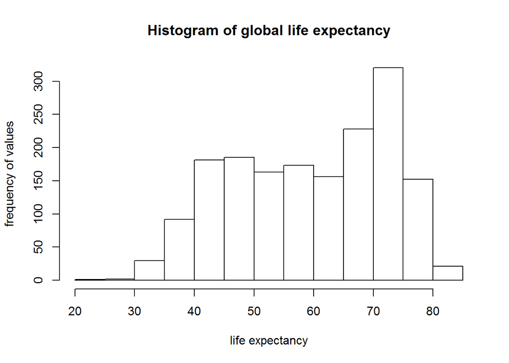

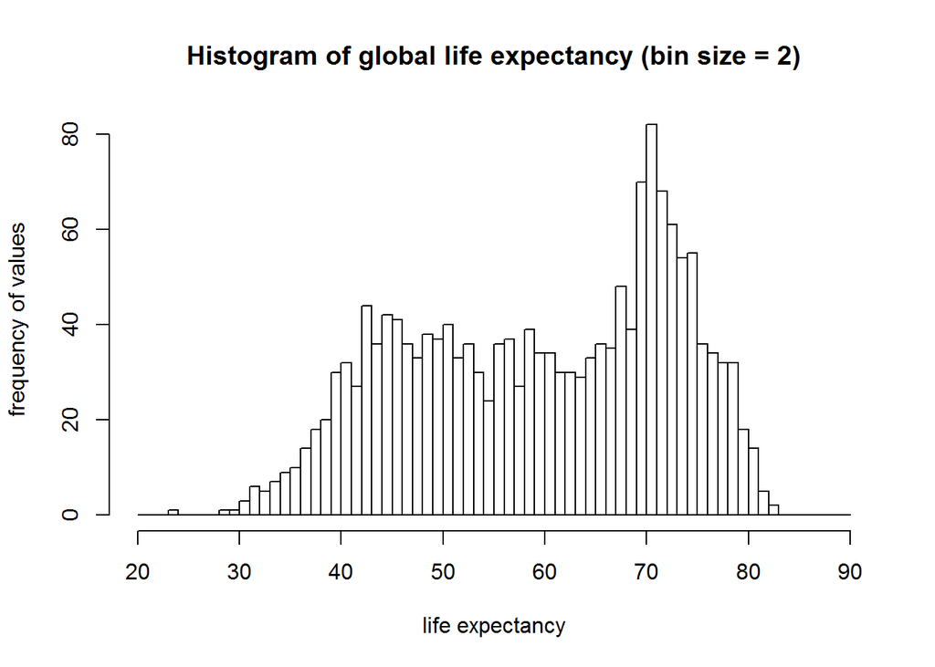

*Looks like there are two peaks, one at 45, and one at ~72 years old.*